# STAT 240 Discussion 10

## Group 319C

## LILY FRANKS, **HAOXUAN LU**, SHRUTHI SRINIVASAN, MICHAEL HANDLER

## Data

### 1

> Calculate the mean and standard deviation of the average July temperature separately for early Madison and recent Madison.

```r
q1 = mw_july%>%
  group_by(era)%>%
  summarize(mean = mean(tavg), sd = sd(tavg))
q1
```

```
## # A tibble: 2 x 3
##   era     mean    sd
##   <chr>  <dbl> <dbl>
## 1 early   72.7  2.29
## 2 recent  72.0  2.94
```

### 2

> Make a plot with separate density curves for the early and recent July average temperatures.

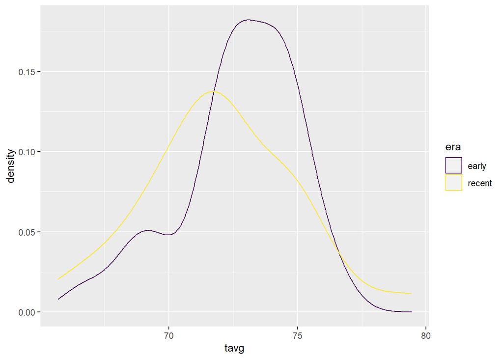

```r
mw_july%>%
  group_by(era)%>%
  ggplot(aes(x = tavg, color = era)) +
  geom_density()
```

### 3

> Treat the 30 years in each time period as separate samples. Use the formulas in the instructions HTML to find 95% confidence intervals for the average July temperature in each time period. Compare results with the output of the `t.test()` function in the chunk below.

```r
x1 <- mw_july %>%
  filter(era=="early") %>%
  pull(tavg)

t.test(x1)
```

```
##
##  One Sample t-test
##
## data:  x1
## t = 173.77, df = 29, p-value < 2.2e-16
## alternative hypothesis: true mean is not equal to 0
## 95 percent confidence interval:
##  71.86239 73.57417
## sample estimates:
## mean of x
##  72.71828
```

```r
x2 <- mw_july %>%
  filter(era=="recent") %>%
  pull(tavg)

t.test(x2)
```

```
##
##  One Sample t-test
##
## data:  x2
## t = 134.06, df = 29, p-value < 2.2e-16
## alternative hypothesis: true mean is not equal to 0
## 95 percent confidence interval:
##  70.89096 73.08754
## sample estimates:
## mean of x
##  71.98925
```

```r
#early era CI
# sd
s1 = q1%>%
  filter(era=="early")%>%
  pull(sd)

#xbar
xbar1 = q1%>%
  filter(era=="early")%>%
  pull(mean)

# t*
x1t = qt(.025, 29)

early_CI <- tibble(early_UCL = xbar1 + (x1t * (s1 / sqrt(30))),
                   early_LCL = xbar1 - (x1t * (s1 / sqrt(30)))
                   )
early_CI
```

```
## # A tibble: 1 x 2
##   early_UCL early_LCL
##       <dbl>     <dbl>
## 1      71.9      73.6
```

```r
#recent era CI

# sd
s2 = q1%>%
  filter(era=="recent")%>%
  pull(sd)

#xbar
xbar2 = q1%>%
  filter(era=="recent")%>%
  pull(mean)

recent_CI <- tibble(recent_UCL = xbar2 + (x1t * (s2 / sqrt(30))),
                    recent_LCL = xbar2 - (x1t * (s2 / sqrt(30)))
                    )
recent_CI
```

```
## # A tibble: 1 x 2
##   recent_UCL recent_LCL
##        <dbl>      <dbl>
## 1       70.9       73.1
```

The results of the confidence intervals presented in the one sample t-test output of the t.test() function is reflected in the confidence intervals we constructed.

### 4

> Draw a graph of a t distribution with 29 degrees of freedom and with the middle 95% of the distribution shaded in.

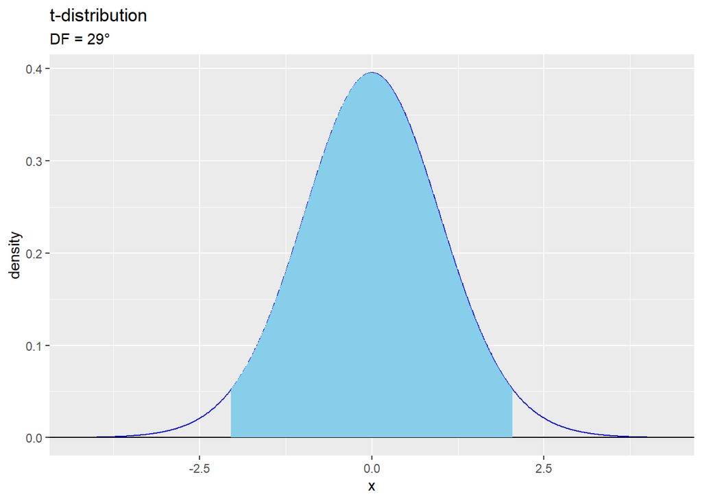

```r
gt(df = 29)+
 geom_t_fill(df= 29, a=qt(.975, 29), b=qt(.025, 29), fill = "skyblue") +
  labs(title = "t-distribution",
       subtitle = "DF = 29°")
```

### 5

> Find a 95% confidence interval for the change (early minus recent) of average July temperatures in Madison. Calculate the difference in sample means and calculate the standard error for the difference. Use the `t.test()` function result to find the estimated degrees of freedom. Find the critical $t^*$ value for a 95% confidence interval for this number of degrees of freedom. Verify that the hand calculation for the confidence interval matches the `t.test()` result.

```r
t.test(x1,x2)
```

```
##
##  Welch Two Sample t-test
##
## data:  x1 and x2
## t = 1.0708, df = 54.733, p-value = 0.2889
## alternative hypothesis: true difference in means is not equal to 0
## 95 percent confidence interval:
##  -0.6354802  2.0935447
## sample estimates:
## mean of x mean of y
##  72.71828  71.98925
```

```r
x5_a <- mean(x1) - mean(x2) + qt(0.025,54.733) * sqrt(sd(x1)^2/30 + sd(x2)^2/30)
x5_a
```

```
## [1] -0.63548
```

```r
x5_b <- mean(x1) - mean(x2) + qt(0.975,54.733) * sqrt(sd(x1)^2/30 + sd(x2)^2/30)
x5_b
```

```
## [1] 2.093545
```

### 6

> Test the hypothesis that the mean July temperature in Madison in the early era is equal to that in the recent era versus that alternative that they are different. Calculate the test statistic $t$ from the equations and verify it matches the result from `t.test()`. Write a conclusion in context to interpret the result of this hypothesis test.

```r
t.test(x1,x2)
```

```
##
##  Welch Two Sample t-test
##
## data:  x1 and x2
## t = 1.0708, df = 54.733, p-value = 0.2889
## alternative hypothesis: true difference in means is not equal to 0
## 95 percent confidence interval:
##  -0.6354802  2.0935447
## sample estimates:
## mean of x mean of y
##  72.71828  71.98925
```

```r
t_value <- (mean(x1) - mean(x2)) / sqrt(sd(x1)^2/30 + sd(x2)^2/30)
t_value
```

```
## [1] 1.070839
```

```r
p <- pt((mean(x1) - mean(x2)) / sqrt(sd(x1)^2/30 + sd(x2)^2/30), 54.733, lower.tail = FALSE)*2
p
```

```
## [1] 0.2889411
```

- Because p_value=0.2889>0.05, we failed to reject the null hypothesis

### 7

> Make a plot of the t distribution for the previous problem. Add a vertical line at the test statistic and shade in the two tail areas that correspond to the p-value.

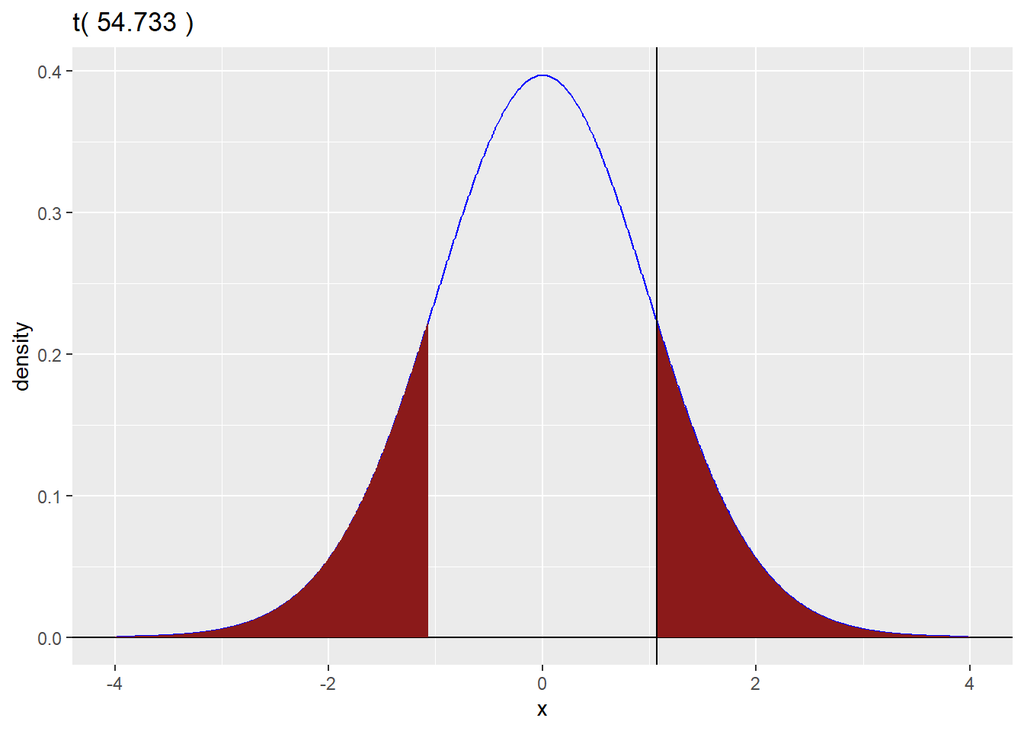

```r
gt(54.733)  +
  geom_t_fill(54.733, a = -4,b = -t_value) +
  geom_t_fill(54.733, a = t_value, b = 4) +
  geom_vline(xintercept = t_value)
```